# HW3

Rohit Chundru 1888308

2/20/2020

# Problem 1

### 1A

mean = .10/(1-0-0.4) mean = 0.1667

### 1B

The AR(2) model is stationary because -1<.04<1, 0+.04<1, and .04-0<1.

### 1C

r(101) = 0.10 + 0.4(0.02) + 0 r(101) = 0.108

r(102) = 0.10 + 0.4(-0.01) + 0 r(102) = 0.096

# Problem 2

### 2A

```r
library(zoo)
library(forecast)
library(fpp2)
library(fBasics)
library(lmtest)
setwd("C:/Users/rohit/Desktop/")
napm = read.csv(file="NAPM.csv")
head(napm)
```

```
##       date index
## 1 1/1/1980  46.2
## 2 2/1/1980  50.2
## 3 3/1/1980  43.6
## 4 4/1/1980  37.4
## 5 5/1/1980  29.4
## 6 6/1/1980  30.3
```

```r
napm$date = as.Date(as.character(napm$date), format='%m/%d/%Y')
str(napm)
```

```
## 'data.frame':    432 obs. of  2 variables:
##  $ date : Date, format: "1980-01-01" "1980-02-01" ...
##  $ index: num  46.2 50.2 43.6 37.4 29.4 30.3 35 45.5 50.1 55.5 ...
```

```r
napm = napm[order(napm$date),]
napm<- ts(napm[, "index"], frequency = 12)
```

There are 432 observations.

### 2B

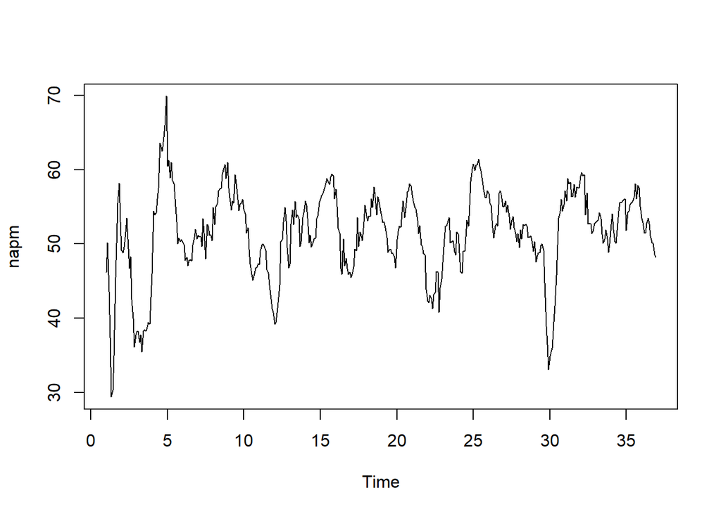

```r
plot(napm)
```

There appears to be no trend or seasonality.

### 2C

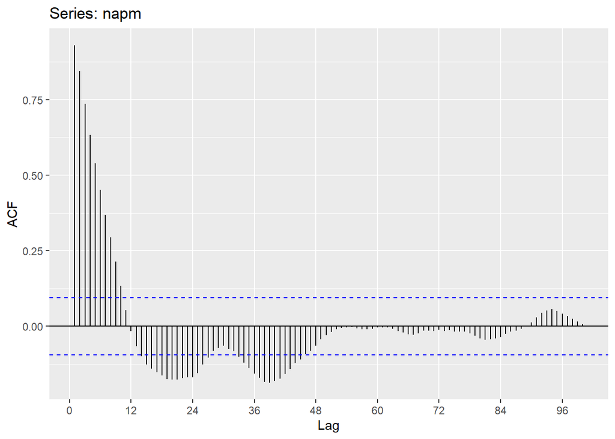

```r
ggAcf(napm, lag.max=100)
```

```r
Box.test(napm, lag=10, type = "Ljung")
```

```
##
##  Box-Ljung test
##
## data:  napm
## X-squared = 1444.3, df = 10, p-value < 2.2e-16
```

Given the p-value and the acf plot, we can see that the data is not white noise, thus correlated.

### 2D

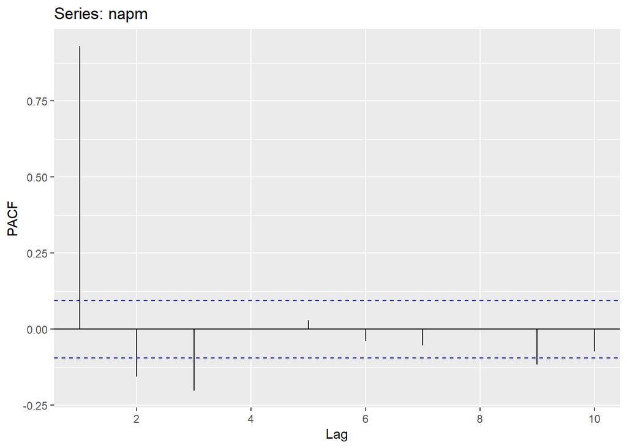

```r
ggPacf(napm, lag.max = 10)
```

Since there three significant spikes at beginning, this data is AR(3).

### 2E

```r
m =Arima(napm, order = c(3,0,0), include.constant = F)
coeftest(m)
```

```
##
## z test of coefficients:
##
##      Estimate Std. Error z value  Pr(>|z|)
## ar1  1.109872   0.047915 23.1636 < 2.2e-16 ***
## ar2  0.023820   0.072936  0.3266  0.743985
## ar3 -0.134955   0.048462 -2.7847  0.005357 **
## ---
## Signif. codes:  0 '***' 0.001 '**' 0.01 '*' 0.05 '.' 0.1 ' ' 1
```

It looks like ar(2) is not significant.

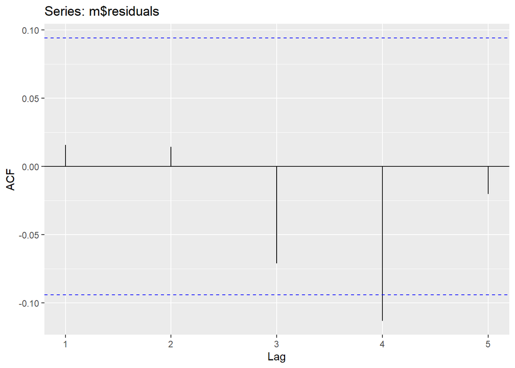

```r
ggAcf(m$residuals, lag.max = 5)
```

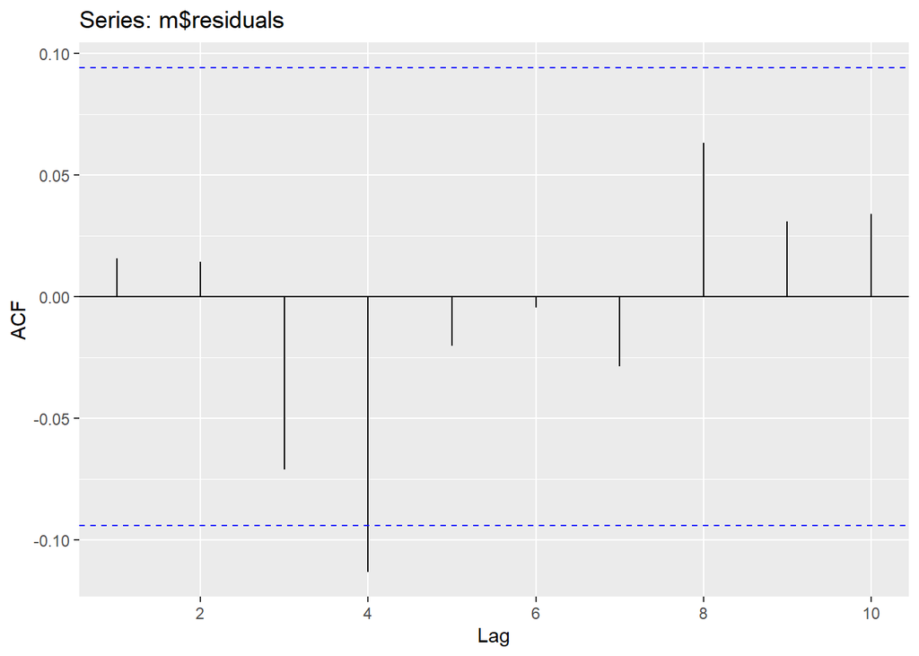

```r
ggAcf(m$residuals, lag.max = 10)
```

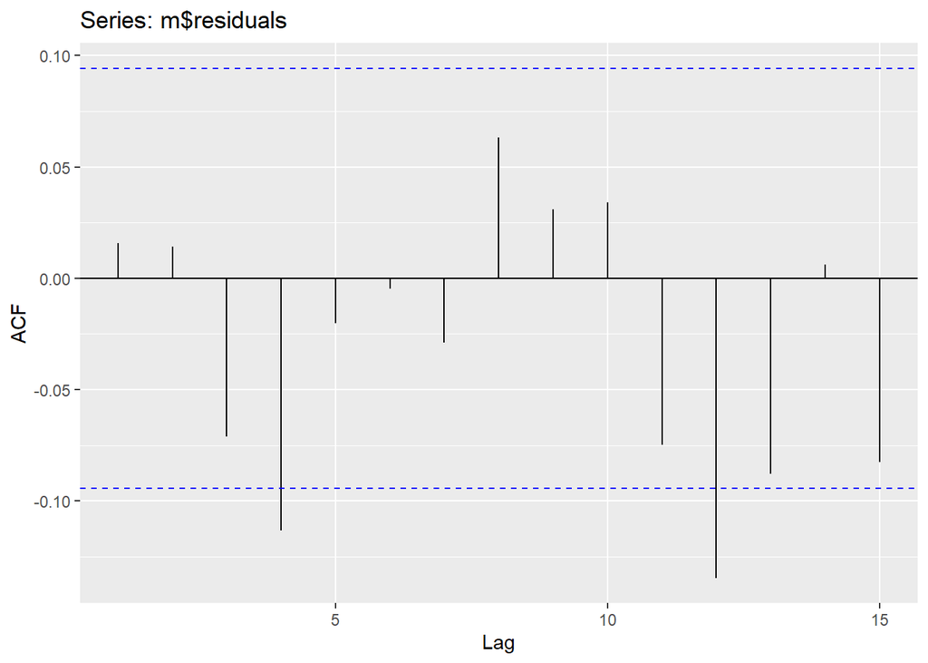

```r
ggAcf(m$residuals, lag.max = 15)
```

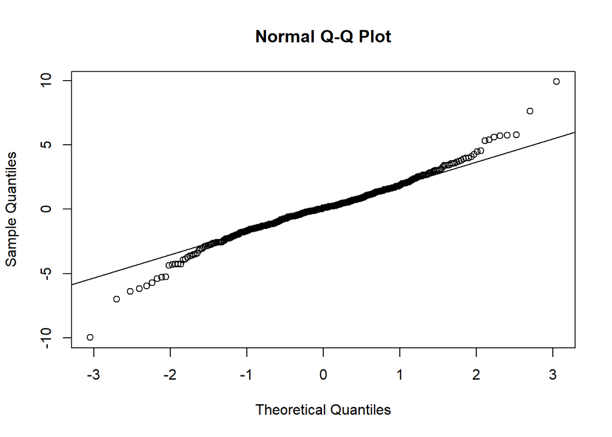

```r
qqnorm(m$residuals)
qqline(m$residuals)
```

### 2F

The coefficients test shows that ar(2) is not sigificant, and the qq plot shows that the residuals are not normal. Therefore this model is not that good.

### 2G

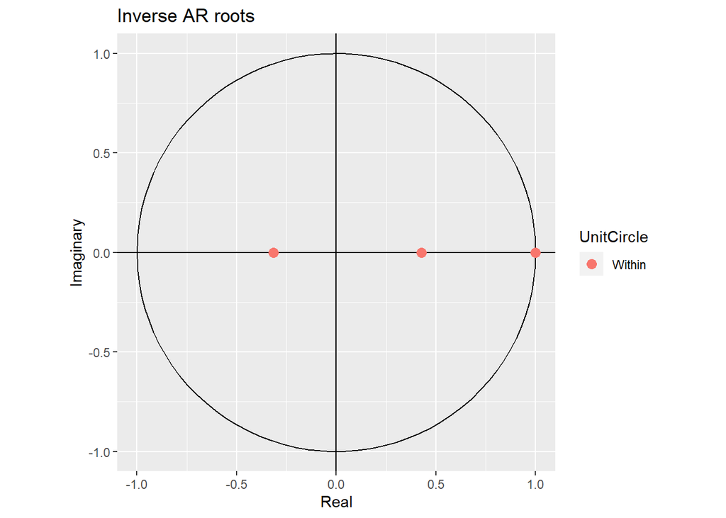

```r
autoplot(m)
```

Since all 3 dots are within the unit circle this model can be considered stationary.

### 2H

```r
step1 = -0.13*(50.1) + 0.02*(48.6) + 1.11*(48.2)
step1
```

```
## [1] 47.961
```

```r
step2 = -0.13*(48.6) + 0.02*(48.2) + 1.11*(47.961)
step2
```

```
## [1] 47.88271
```

```r
step3 = -0.13*(48.2) + 0.02*(47.961) + 1.11*(47.88)
step3
```

```
## [1] 47.84002
```

```r
step4 = -0.13*(47.961) + 0.02*(47.88) + 1.11*(47.84)
step4
```

```
## [1] 47.82507
```

```r
step5 = -0.13*(47.88) + 0.02*(47.84) + 1.11*(47.83)
step5
```

```
## [1] 47.8237
```

### 2I

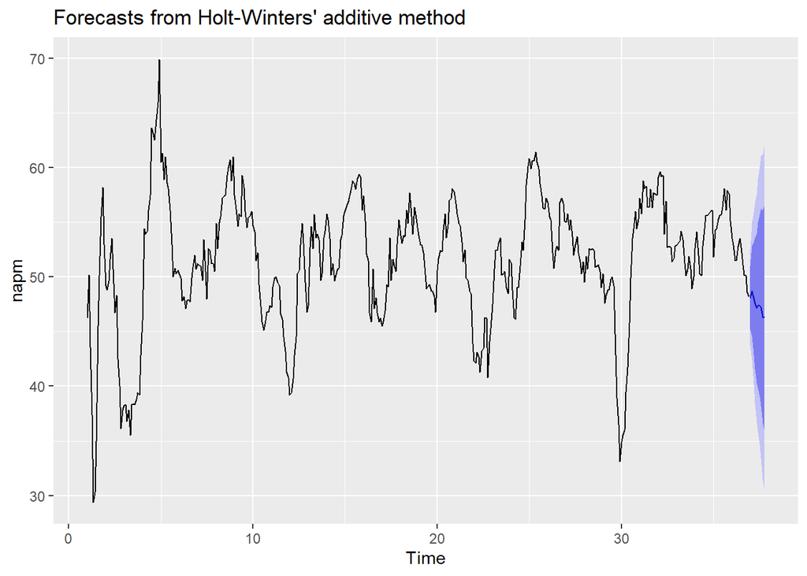

```r
model = hw(napm, h=10);
autoplot(model)
```

The trend is consistent with the observed dynamic behaviour.

# Problem 3

### 3A

```r
groceries = read.csv('C:/Users/rohit/Desktop/groceries.csv')
head(groceries)
```

```
##        Date ToothPaste PeanutButter Biscuits
## 1  6-Jan-08        224          462      381
## 2 13-Jan-08        235          488      398
## 3 20-Jan-08        226          431      349
## 4 27-Jan-08        226          495      397
## 5  3-Feb-08        222          439      367
## 6 10-Feb-08        215          452      366
```

```r
groceries$Date = as.Date(as.character(groceries$Date), format='%d-%b-%y')
str(groceries)
```

```
## 'data.frame':    52 obs. of  4 variables:
##  $ Date        : Date, format: "2008-01-06" "2008-01-13" ...
##  $ ToothPaste  : int  224 235 226 226 222 215 221 213 213 220 ...
##  $ PeanutButter: int  462 488 431 495 439 452 475 413 470 455 ...
##  $ Biscuits    : int  381 398 349 397 367 366 397 347 387 388 ...
```

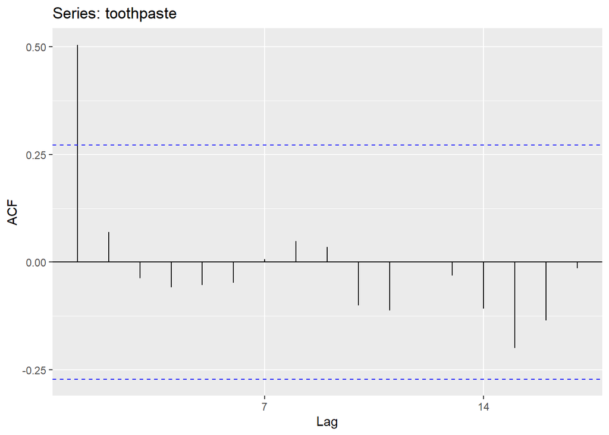

```r
groceries = groceries[order(groceries$Date),]
toothpaste<- ts(groceries[, "ToothPaste"], frequency = 7)
ggAcf(toothpaste)
```

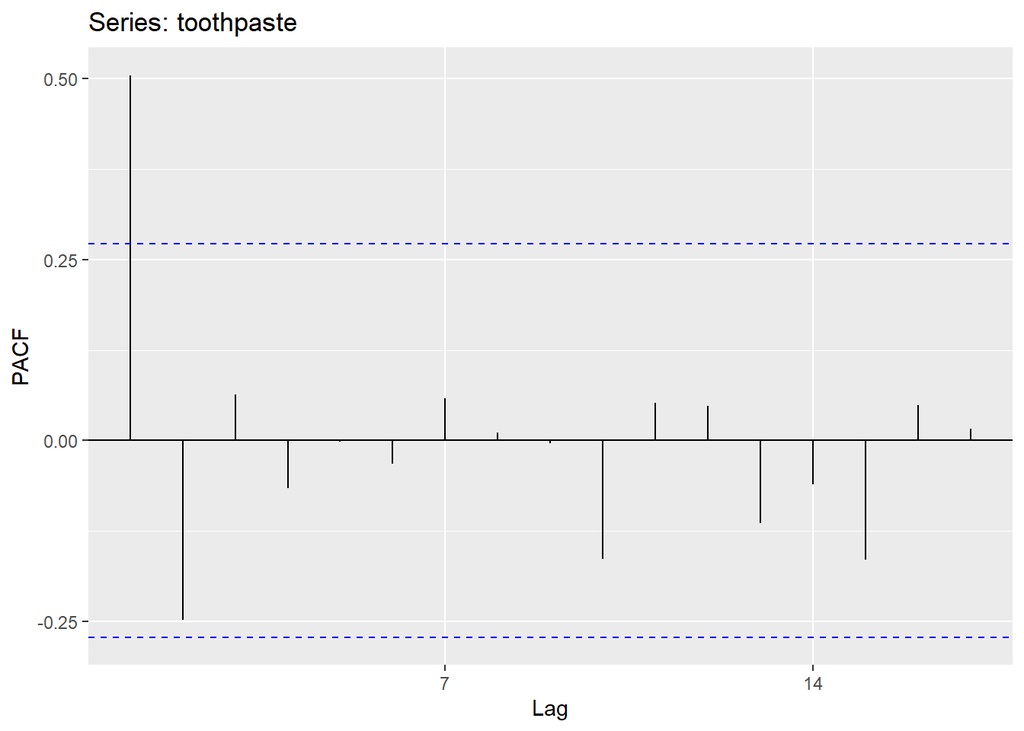

```r
ggPacf(toothpaste)
```

The ACF and PACF plots suggest the model is both AR1 and MA1.

### 3B

```r
m =Arima(toothpaste, order = c(1,0,1), include.constant = F)
coeftest(m)
```

```
##
## z test of coefficients:
##
##        Estimate  Std. Error   z value Pr(>|z|)
## ar1  0.99987852  0.00020981 4765.5425   <2e-16 ***
## ma1 -0.36765441  0.30786412   -1.1942   0.2324
## ---
## Signif. codes:  0 '***' 0.001 '**' 0.01 '*' 0.05 '.' 0.1 ' ' 1
```

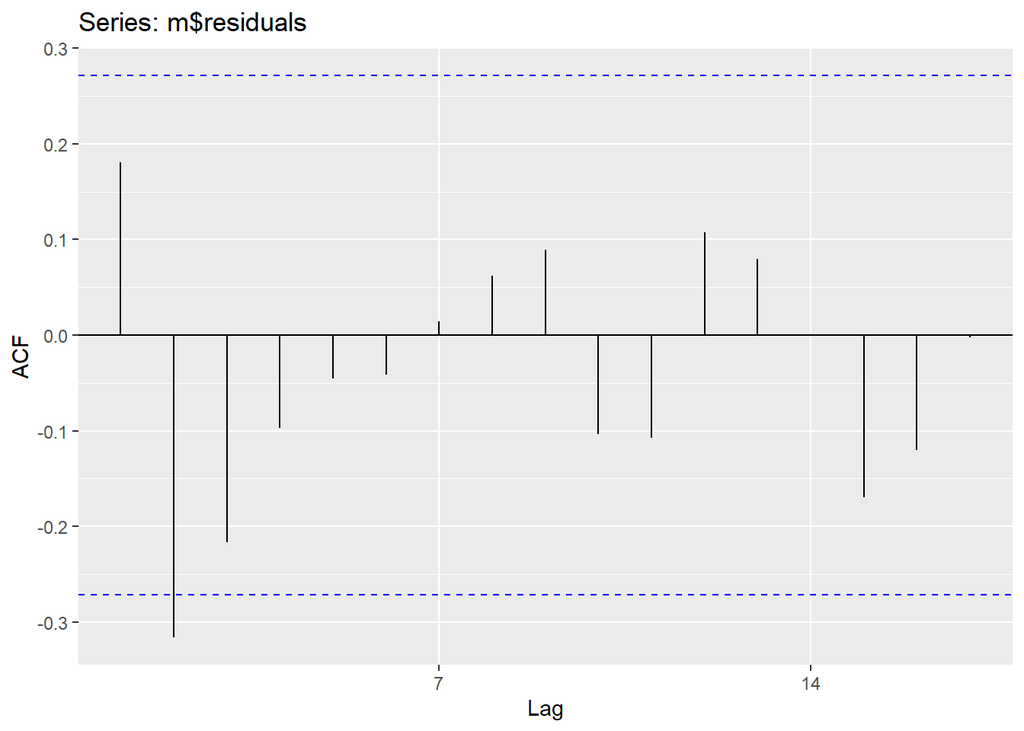

```r
ggAcf(m$residuals)
```

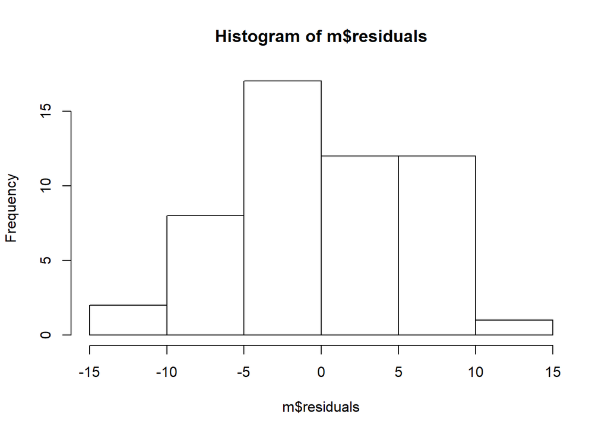

```r
hist(m$residuals)
```

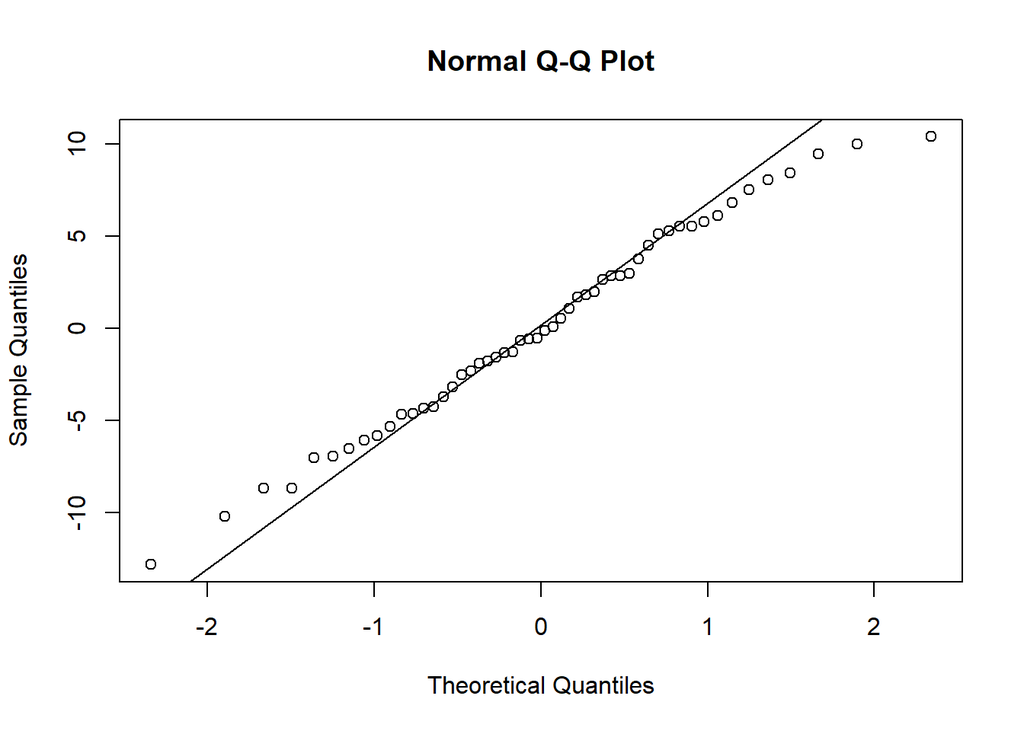

```r
qqnorm(m$residuals)
qqline(m$residuals)
```

### 3C

xt =0.99(xt-1) this does represent stationary behaviour because -1<0.99<1